# 9.0 Portfolio assignment 9

25 min: Perform a bivariate analysis on the columns with numerical data in the penguins dataset.

- Use corr() on the DataFrame to calculate all the correlations. Use the code example above to show the correlation table with colors.
- Look at the corrrelations. Do they match your expectations?
- Show a scatter plot for
  - The strongest positive correlation
  - The strongest negative correlation
  - The weakest correlation

```python
import pandas as pd
import seaborn as sns

penguins = sns.load_dataset("penguins")
```

[figure not shown]

## 9.1 Correlations penguin data set

```python
penguins.corr().style.background_gradient(cmap='coolwarm', axis=None).format(precision=2)
```

|  | bill_length_mm | bill_depth_mm | flipper_length_mm | body_mass_g |
| --- | --- | --- | --- | --- |
| bill_length_mm | 1.00 | -0.24 | 0.66 | 0.60 |
| bill_depth_mm | -0.24 | 1.00 | -0.58 | -0.47 |
| flipper_length_mm | 0.66 | -0.58 | 1.00 | 0.87 |
| body_mass_g | 0.60 | -0.47 | 0.87 | 1.00 |

#### Observaties

- Een hoge positieve correlatie tussen body_mass_g (gewicht) en flipper_length_mm (lengte flipper) is logisch, bij een langere flipper zal een pinguin ook meer wegen
- Een sterke negatieve correlatie bestaat tussen flipper_length_mm (lengte flipper) en bill_depth_mm (diepte bek). Namelijk hoe kleiner de lengte van de flipper, hoe dieper de bek is

## 9.2 Strongest positive correlation

De "strongest positive correlation" ligt tussen de kolommen body_mass_g (Lichaamsgewicht) en flipper_length_mm (Lengte flipper in milimeter)

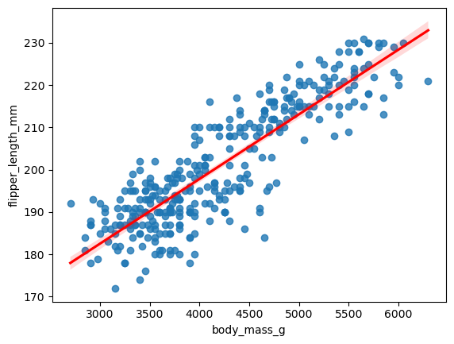

```python
sns.regplot(data=penguins, x='body_mass_g', y='flipper_length_mm', fit_reg=True, line_kws={"color": "red"})
```

## 9.2 Strongest negative correlation

De "Strongest negative correlation" ligt tussen de kolommen flipper_length_mm en bill_depth_mm

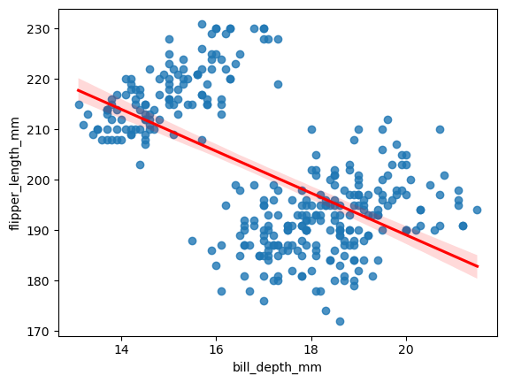

```python
sns.regplot(data=penguins, x='bill_depth_mm', y='flipper_length_mm', fit_reg=True, line_kws={"color": "red"})
```

## 9.3 Weakest correlation

De zwakste correlatie ligt tussen de kolommen bill_depth_mm en bill_length_mm

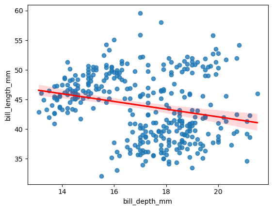

```python
sns.regplot(data=penguins, x='bill_depth_mm', y='bill_length_mm', fit_reg=True, line_kws={"color": "red"})
```